# Regridding of Globcolour dataset

### Applying a regional mask

A regional analysis may be informative, as different regions may follow different annual patterns of ice retreat and ice advance, which may over time lead to a difference in species distribution or other factors which could affect the syncronicity between ice retreat and phytoplankton bloom. For this reason, a regional mask was applied. This mask was supplied by Prof. Stroeve, defining the major regions in the Arctic. The below table shows the values of the regional mask:

| Number | region |
| --- | --- |
| 0 | non-ocean water |
| 1 | Other |
| 2 | Sea of Okhotsk |
| 3 | Bearing sea |
| 4 | Hudson |
| 5 | St. Lawrence |
| 6 | Baffin Bay |
| 7 | East Greenland |
| 8 | Barents |
| 9 | Kara |
| 10 | Laptev sea |
| 11 | East siberian sea |
| 12 | Chuckchi |
| 13 | Beaufort |
| 14 | CCA |
| 15 | Central arctic |
| 20 | Land Mask |
| 21 | coastline |

The regional analysis is focused on Arctic regions, and other regions (including region 0 in the above) are dropped from the dataset.

```r
regional_mask_table <- read.csv("../DATA/regional_mask/NAMES.csv")
names(regional_mask_table)[1] <- "region_number"
regional_mask <- raster("../DATA/regional_mask/mask_geotiff.tif")
#list of unique values from the regional mask  (shown in order)
regional_values <- regional_mask %>%
  as.matrix() %>%
  c() %>%
  unique()
regional_values[order(regional_values)]
```

```
 [1]  0  1  2  3  4  5  6  7  8  9 10 11 12 13 14 15 20 21
```

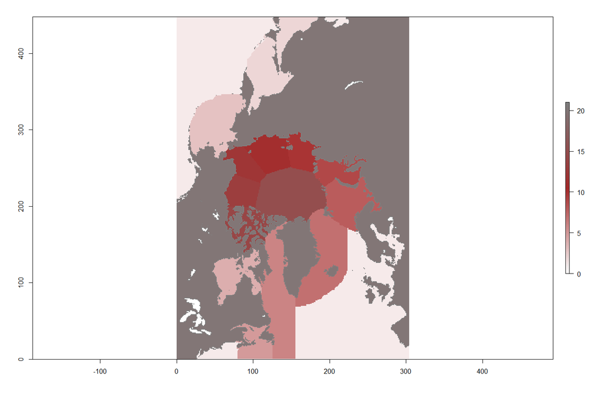

```r
#plot image of regional mask to show definition of regions (N.B. apply labels to image)
raster::plot(
  regional_mask,
  useRaster = TRUE,
  gridded = TRUE,
  nrow = 448,
  ncol = 304,
  col = colorRampPalette(c("white", "brown", "gray50"))(255),
  drawExtent=TRUE
  )
```

```r
#Notice that there are values 20 and 21 (Land and coast, respectively)
regional_mask <- as.matrix(regional_mask) # convert to matrix
unique(c(regional_mask))[order(unique(c(regional_mask)))]
```

```
 [1]  0  1  2  3  4  5  6  7  8  9 10 11 12 13 14 15 20 21
```

```r
#which(regional_mask == 21,arr.ind = TRUE) #finds the 2-d co-ordinate space of each coastline pixel
#which(regional_mask == 20,arr.ind = TRUE) #finds the 2-d co-ordinate space of each non-ocean open water pixel
#non_ocean <- which(regional_mask == 20,arr.ind = TRUE) #finds the 2-d co-ordinate space of each non-ocean open water pixel
#coast <- which(regional_mask == 21,arr.ind = TRUE) #finds the 2-d co-ordinate space of each non-ocean open water pixel
#coast[coast[,1] == max(coast[,1]),] #highest coastline pixel on image
#make into same long format as main dataset.
regional_mask <-
  data.frame(pixel_number = 1:(dim(regional_mask)[1] * dim(regional_mask)[2]),
  region_number = c(regional_mask),
  stringsAsFactors = FALSE)
regional_mask <- regional_mask %>%
  left_join(regional_mask_table,by="region_number")
```